# Softver R moje poznamky uvod do prace v R - Grafika v R

Dominik Zatkalik, citovane materialy Tomas Bacigal

dnes

Uvod do R ka je v nadradenej stranke r.htm

cite Tomas Bacigal:

# Náhodná premenná, rozdelenie pravdepodobnosti

## Najbežnejšie diskrétne rozdelenia pravdepodobnosti

### Binomické rozdelenie

parametre rozdelenia

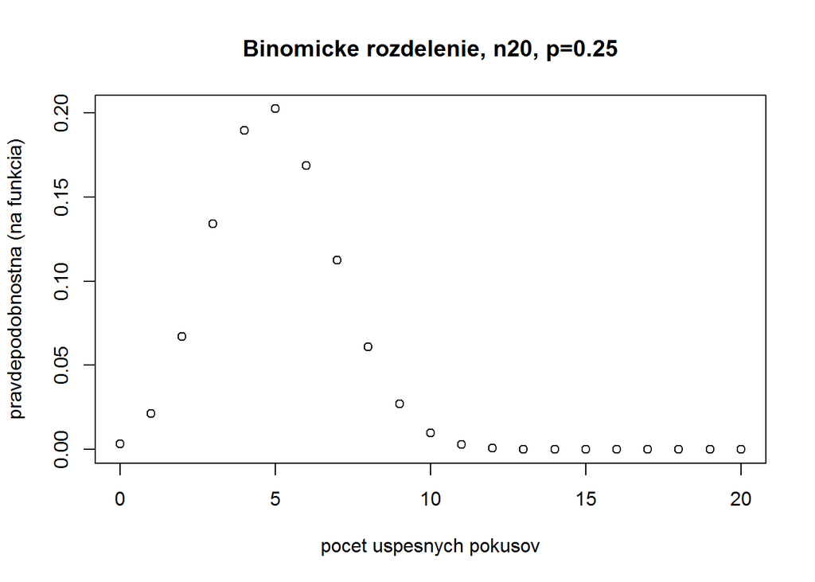

```r
n <- 20 #pocet pokusov
p <- 0.25 # pravdepodobnost udalosti v jednom pokuse

x <- 0:n
plot(x, y=dbinom(x, size=n, prob=p), xlab="pocet uspesnych pokusov", ylab="pravdepodobnostna (na funkcia)", main = "Binomicke rozdelenie, n20, p=0.25")
```

Stredna hodnota E(X)

```r
n*p
```

```
## [1] 5
```

Disperzia D(X)

```r
n*p*(1-p)
```

```
## [1] 3.75
```

Teoreticky median

```r
qbinom(0.5, size = n, prob = p)
```

```
## [1] 5
```

Nahodbny vyber z binomickeho rozdelenia

```r
y <- rbinom(30, size = n, prob = p)
median(y) #vyberovy median
```

```
## [1] 6
```

Pravdepodobnost uspechu najviac v 3 pokusoch

```r
pbinom(3, n, p)
```

```
## [1] 0.225156
```

Pravdepodobnost uspechu v aspon 10 pokusoch

```r
1-pbinom(9,n,p)
```

```
## [1] 0.01386442
```

Pravdepodobnost uspechu vo viac ako 10 pokusoch

```r
1-pbinom(10,n,p)
```

```
## [1] 0.003942142
```

Nanajvys kolko uspesnych pokusov mozno ocakavat s 90% pravdepodobnostou

```r
qbinom(0.90, n, p)
```

```
## [1] 8
```

### Poissnovo rozdelenie

je aproximaciou Binomickeho rozdelenia pre male p a velke n, procom parameter rozdelenia lambda = n*p

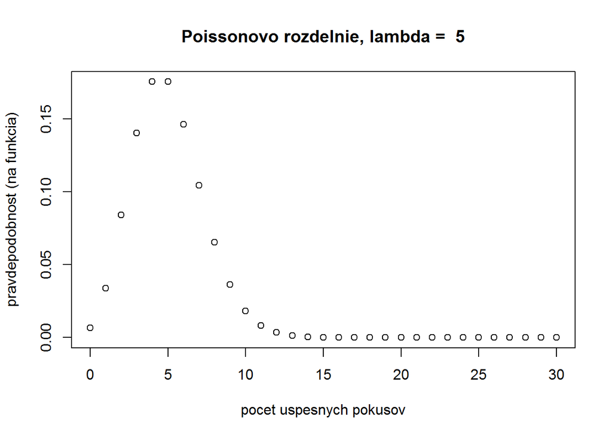

```r
lambda <-5

x <- 0:30

plot(x,
     y = dpois(x, lambda),
     xlab = "pocet uspesnych pokusov",
     ylab = "pravdepodobnost (na funkcia)",
     main = paste("Poissonovo rozdelnie, lambda = ", lambda)
     )
```

#### Priklad

Podla statistickych tabuliek pravdepodobnost dozitia sa nasledujuceho roku u 25-rocneho muza je priblizne 0.998. Poistovna ponuka muzom tohoto veku, ze pri rocnom poistnom 50 EUR vyplati pozostalym v pripade umrtia poisteneho sumu 8000 EUR. Je poistenych tisic 25-rocnych muzov. Aka je pravdepodobnost, ze ku koncu roka bude zisk poistovne aspon 30 000 EUR? Riesenie: Nech X je nah.premenna pocet umrti poistencov a Z nahodna premenna zisk poistovne. Potom plati Z = 501000 - 8000X. Hladame pravdepodobnost P(Z > =30 000) = P(50 000 - 8 000*X >= 30 000) = P(X <= 2.5) = F(2.5) =

```r
ppois(2.5, lambda = 1000*(1-0.998))
```

```
## [1] 0.6766764
```

kedze X ma Poisonovo rozdelenie s parametrom lambda=1000*(1-0.998).

#### cvicenie

V pristroji je 2000 suciastok. Pravdepodobnost zlyhania jednej je 0.005. Nahodna premenna X je pocet zlyhanych suciastok, X ma Poisonovo rozdelenie pravdepodobnosti.

Vypocitajte parameter Poisonovho rozdelenia a vygenerujte z neho 20 nahodnych cisel.

Vypocitajte vyberovy median a porovnajte ho s teoretickym medianom.

Aka je pravdepod. ze zlyha viac ako 10 suciastok?

## Najbežnejšie spojité rozdelenia pravdepodobnosti

### Normálne rozdelenie

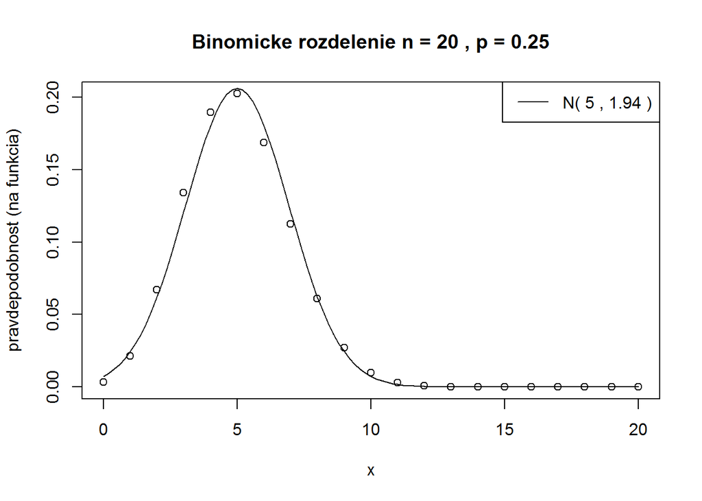

```r
p <- 0.25
n <- 20
x <- 0:n
plot(x,
     y = dbinom(x, size = n, prob = p),
     ylab = "pravdepodobnost (na funkcia)",
     main = paste("Binomicke rozdelenie n =", n, ", p =", p)
     )
plot(function(x) dnorm(x, mean = n*p, sd=sqrt(n*p*(1-p))), from=min(x), to= max(x), add=T)
legend("topright", paste("N(",n*p,",",round(sqrt(n*p*(1-p)),2),")"), lty = 1)
```

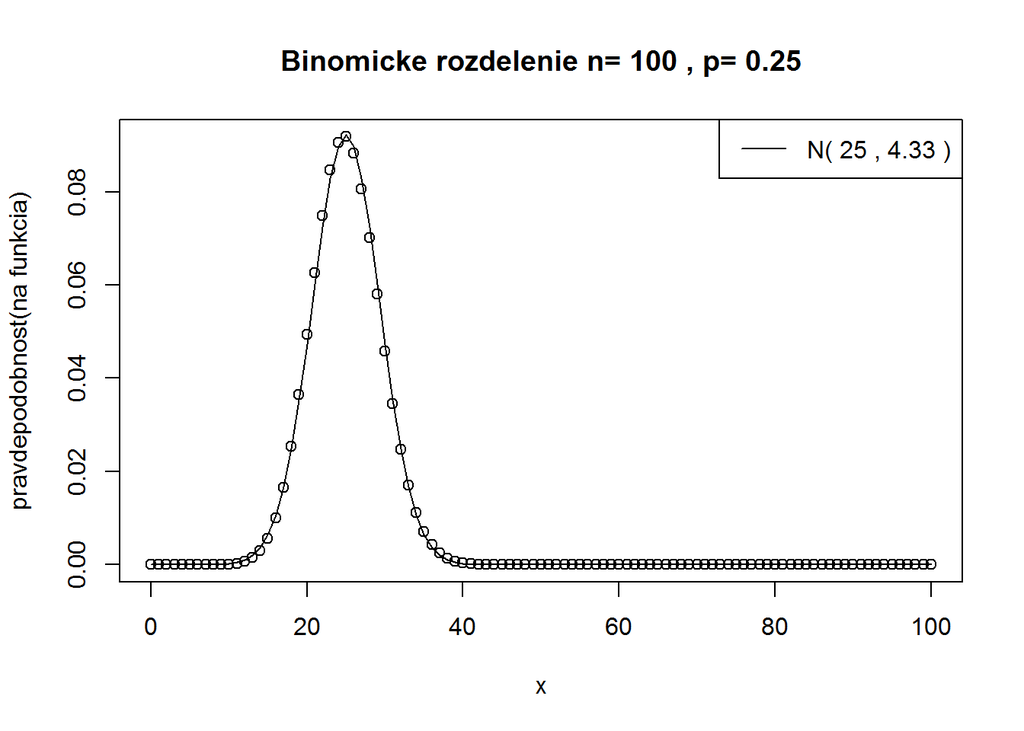

```r
n <- 100
x <- 0:n
mu <- n*p
sig <- sqrt(n*p*(1-p))
plot(x,
     y = dbinom(x, size = n, prob =p),
     ylab = "pravdepodobnost(na funkcia)",
     main=paste("Binomicke rozdelenie n=", n, ", p=", p)
)
plot(function(x) dnorm(x, mean=mu, sd=sig), from=min(x), to=max(x), add=T)
legend("topright", paste("N(",mu,",",round(sig,2),")"), lty=1)
```

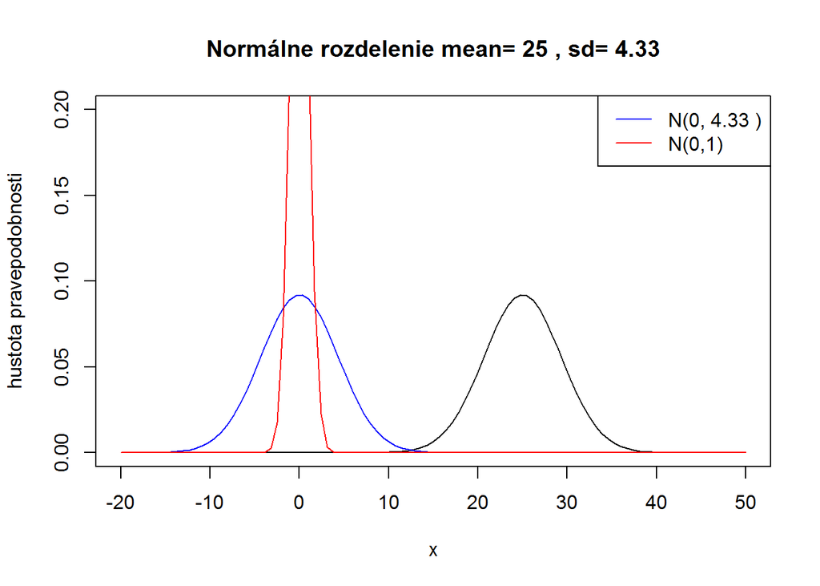

```r
plot(function(x) dnorm(x, mean=mu, sd=sig),
     xlim=c(-20,50), ylim=c(0,0.2),
     ylab = "hustota pravepodobnosti",
     main=paste("Normálne rozdelenie mean=", mu, ", sd=", round(sig,2))
)
plot(function(x) dnorm(x, mean=0, sd=sig ),
     from=-20, to=50, col="blue", add=T)
plot(function(x) dnorm(x, mean=0, sd=1),
     from=-20, to=50, col="red", add=T)
legend("topright", legend=c(paste("N(0,",round(sig,2),")"), "N(0,1)"),
       col=c("blue", "red"), lty=c(1,1))
```

Ak majú dve nezávislé náhodné premenné X1 a X2 normálne rozdelenie, X1~N(m1,s1) a X2~N(m2,s2), potom ich lineárna kombinácia Y = aX1 + bX2 + c je tiez nahodna premenna s normalnym rozdelenim, Y~N(am1+bm2+c, a^2 * s1^2 + b^2 * s2^2).

### loh-Normálne rozdelenie

Ak X~N(m,s), potom náhodná premenná Y = e^X má LN(m,s).

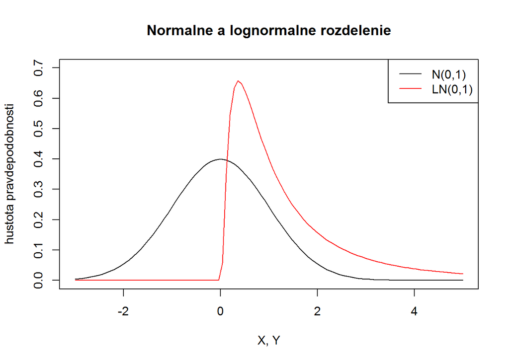

```r
plot(function(x) dnorm(x, mean = 0, sd=1),
     xlim = c(-3,5), ylim = c(0,0.7),
     ylab = "hustota pravdepodobnosti",
     xlab = "X, Y",
     main = "Normalne a lognormalne rozdelenie"
     )
plot(function(x) dlnorm(x, meanlog = 0, sdlog = 1),
     from = -3, to = 5, col = "red", add=T)
legend("topright", legend = c("N(0,1)", "LN(0,1)"),
       col = c("black", "red"), lty = c(1,1))
```

Veľa náhodných veličín v prírode má rozdelenie blízke lognormálnemu (definované na kladnej reálnej osi), ich logaritmovaním môžme na analýzu/modelovanie použiť množstvo štatistických metód vyžadujúcich normalitu náhodných premenných (napr. t-test, regresia).

### Chi-kvadrat rozdelenie

Ak X1, X2 … Xn maju normovane normálne rozdelenie N(0,1), potom náhodná premenná Y = X1^2 + X2^2 + … Xn^2 má Chi^2(n) rozdelenie s n-stupňami voľnosti. E(Y) = n, D(Y) = 2n

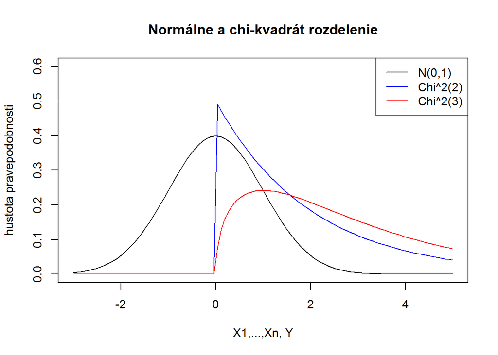

```r
plot(function(x) dnorm(x, mean=0, sd=1 ),
     xlim = c(-3,5), ylim = c(0,0.6),
     ylab = "hustota pravepodobnosti",
     xlab = "X1,...,Xn, Y",
     main="Normálne a chi-kvadrát rozdelenie"
)
plot(function(x) dchisq(x, df=2),
     from=-3, to=5, col="blue", add=T)
plot(function(x) dchisq(x, df=3),
     from=-3, to=5, col="red", add=T)
legend("topright", legend=c("N(0,1)","Chi^2(2)","Chi^2(3)"),
       col=c("black", "blue","red"), lty=c(1,1,1))
```

### Studentovo t rozdelenie

Ak X1~N(0,1) a X2~Chi^2(n), potom Y = X1/sqrt(X2/n) ma t(n) rozdelenie s n stupnami volnosti. E(Y) = 0, D(Y) = n/(n-2)

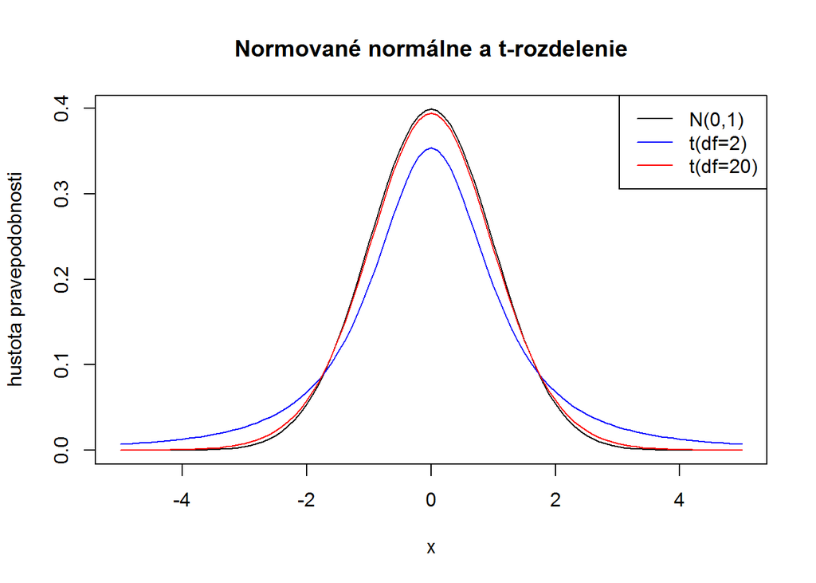

```r
plot(function(x) dnorm(x, mean=0, sd=1),
     xlim=c(-5,5),
     ylab = "hustota pravepodobnosti",
     main="Normované normálne a t-rozdelenie"
)
plot(function(x) dt(x, df=2),
     from=-5, to=5, col="blue", add=T
)
plot(function(x) dt(x, df=20),
     from=-5, to=5, col="red", add=T
)
legend("topright", legend=c("N(0,1)", "t(df=2)", "t(df=20)"),
       col=c("black", "blue", "red"), lty=c(1,1,1))
```

### Fisher-Snedecorovo F-rozdelenie

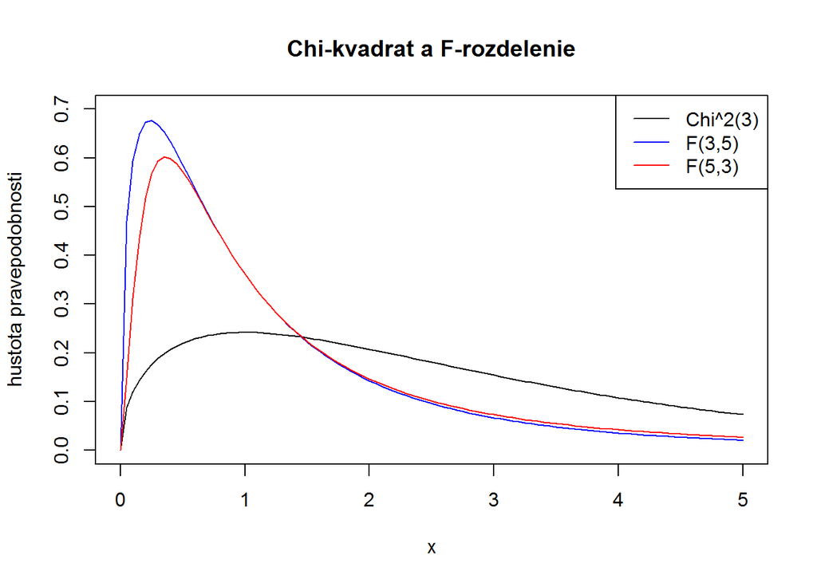

```r
plot(function(x) dchisq(x, df=3),
     xlim=c(0,5), ylim=c(0,0.7),
     ylab = "hustota pravepodobnosti",
     main="Chi-kvadrat a F-rozdelenie"
)
plot(function(x) df(x, df1=3,df=5),
     xlim=c(0,5), col="blue", add=T
)
plot(function(x) df(x, df1=5,df=3),
     xlim=c(0,5), col="red", add=T
)
legend("topright", legend=c("Chi^2(3)", "F(3,5)", "F(5,3)"),
       col=c("black", "blue", "red"), lty=c(1,1,1))
```

### Exponenciálne rozdelenie

Napr. doba zivotnosti zariadenia alebo doba čakania zákazníkov v rade.

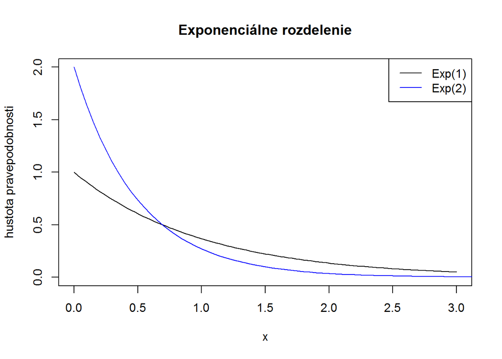

```r
plot(function(x) dexp(x, rate=1),   # rate > 0  (lambda)
    xlim=c(0,3), ylim=c(0,2),
    ylab = "hustota pravepodobnosti",
    main="Exponenciálne rozdelenie"
)
plot(function(x) dexp(x, rate=2),
     xlim=c(0,5), col="blue", add=T
)
legend("topright", legend=c("Exp(1)", "Exp(2)"),
       col=c("black", "blue"), lty=c(1,1))
```

stredna hodnota E(X) = 1/lambda

```r
integrate(function(x) x*dexp(x, rate = 2), -Inf, Inf)$value
```

```
## [1] 0.5
```

median 1/lambda * log(2)

```r
qexp(0.5, rate = 2)
```

```
## [1] 0.3465736
```

disperzia D(x) = (1/lambda)^2

```r
integrate(function(x) ((x-1/2)^2)*dexp(x, rate=2), -Inf, Inf)$value
```

```
## [1] 0.25
```

Spolu s normálnym rozdelením a chi-kvadrát, ale aj binomickým (pre fixné n) a poissonovým rozdelením patrí do tzv. exponenciálnej rodiny rozdelení. Ďalšími v rodine sú beta a gamma (zovšeobecnenie exponenciálneho) rozdelenie. Hustota má tvar f(x|par)=g(x)h(par)exp(a(x)*b(par)).

### Weibulovo rozdelenie

Zovšeobecňuje exponenciálne rozdelenie, ked “failure rate” zavisi od času: ak shape<1, failure rate sa s postupom času znižuje, keďže výrazne slabšie články systému zlyhali ak shape=1, model “bez pamäte” t.j. redukcia na exponenciálne rozdelenie ak shape>1, naopak, ked miera zlyhania sa postupom času zvyšuje

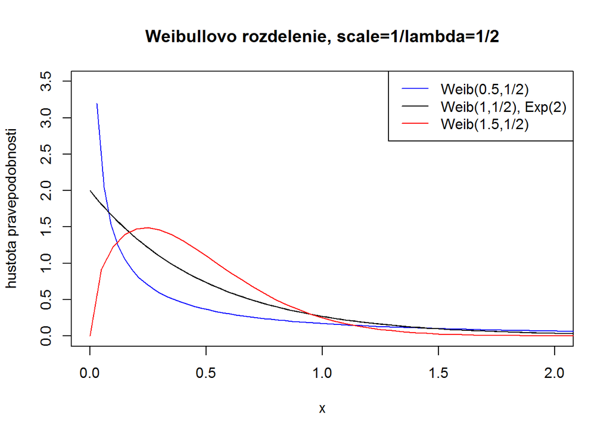

```r
plot(function(x) dexp(x, rate=2),
     xlim=c(0,2), ylim=c(0,3.5),
     ylab = "hustota pravepodobnosti",
     main="Weibullovo rozdelenie, scale=1/lambda=1/2"
)
plot(function(x) dweibull(x, shape=0.5, scale=1/2),
     xlim=c(0,3), col="blue", add=T
)
plot(function(x)  dweibull(x, shape=1, scale=1/2),
     xlim=c(0,5), col="black", add=T
)
plot(function(x)  dweibull(x, shape=1.5, scale=1/2),
     xlim=c(0,5), col="red", add=T
)
legend("topright", legend=c("Weib(0.5,1/2)","Weib(1,1/2), Exp(2)", "Weib(1.5,1/2)"),
       col=c("blue", "black", "red"), lty=c(1,1,1))
```

Používa sa na modelovanie rozdelennia NP: prežitie (poist.), výskyt prepätia v el.sieti, rýchlosť vetra, extrémne udalosti ako zrážky a prietoky (hydrol.) Ďalšie rozdelenia definované na [0,inf) a používané napr. v hydrológii sú Gumbel, GEV, generalized Pareto…

### Cvicenie

Dojazd auta (po najbližšiu poruchu) je náhodná premenná s exponenciálnym rozdelením a strednou hodnotou 5000 km. Na dobrodružnej ceste nás po prejdení 2000km čaká aj púšť s priemerom 1000km, kde niet žiadneho autoservisu. Aká je pravdepodobnosť, že uviazneme práve na tej púšti?

```r
#x <- seq(0,10000,length.out = 1000)
#Rc
#mdrMisc::plotDistr(x, dexp(x,2e-04), regions=list(c(2000,3000)),
#                     ylim=c(0,2e-04)
#)
```

Koľko kilometrov bezporuchovej prevádzky nám auto “garantuje” so spoľahlivosťou 90%? Aké rozdelenie by ste zvolili, aby lepšie vystihovalo prirodzené starnutie vozidla?

# Popisna statistika

## Ciselne charakteristiky

### Miery polohy

stredna hodnota

```r
x1 <- c(2,4, 8, 9, 11, 11, 12)

sum(x1)/length(x1)
```

```
## [1] 8.142857
```

```r
mean(x1)
```

```
## [1] 8.142857
```

```r
x2 <- c(2, 4, 8, 9, 11, 11, 120)
mean(x2)
```

```
## [1] 23.57143
```

median

```r
median(x1) # robustna miera polohy, t.j. necitliva voci vybocujucim meraniam (outliers)
```

```
## [1] 9
```

```r
median(x2)
```

```
## [1] 9
```

geometricky priemer

```r
gm <- function(x) prod(x)^(1/length(x))
gm(x1)  # pri zosikmenych rozdeleniach byva odhad casto blizky medianu
```

```
## [1] 7.015451
```

```r
exp(mean(log(x1)))
```

```
## [1] 7.015451
```

### Miery variability

rozptyl a standardna odchylka

```r
var(x1)
```

```
## [1] 14.47619
```

```r
sd(x1)  # sqrt(var(x1))
```

```
## [1] 3.804759
```

```r
sd(x2)
```

```
## [1] 42.65699
```

medzikvartalove rozpatie

```r
IQR(x1)
```

```
## [1] 5
```

```r
IQR(x2) # rezistentny voci outlierom
```

```
## [1] 5
```

```r
quantile(x1, probs=0.25)   #dolny kvartil
```

```
## 25%
##   6
```

stredna absolutna odchylka

```r
median(abs(x1-median(x1)))
```

```
## [1] 2
```

```r
median(abs(x2-median(x2)))
```

```
## [1] 2
```

### Miery sikomsti (asymetrie)

klasicka miera sikomosti

```r
( n <- length(x1) )
```

```
## [1] 7
```

```r
sum((x1-mean(x1))^3) / sd(x1)^3 * n/((n-1)*(n-2))
```

```
## [1] -0.8398416
```

```r
sikmost <- function(x) {
  sum((x-mean(x))^3) / sd(x)^3 *
    length(x)/((length(x)-1)*(length(x)-2))
}
sikmost(x1)
```

```
## [1] -0.8398416
```

## Graficke charakteristiky

### histogram a kobercovy graf

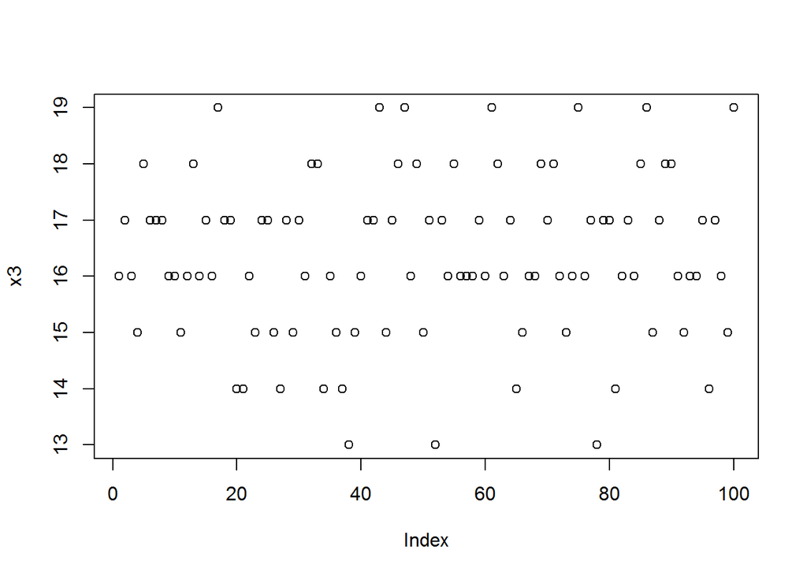

```r
set.seed(10)
x3 <- rbinom(100, size=20, prob=0.8)
plot(x3)  #malo informativne
```

```r
table(x3) # tabulka pocetnosti
```

```
## x3
## 13 14 15 16 17 18 19
##  3  8 14 29 26 13  7
```

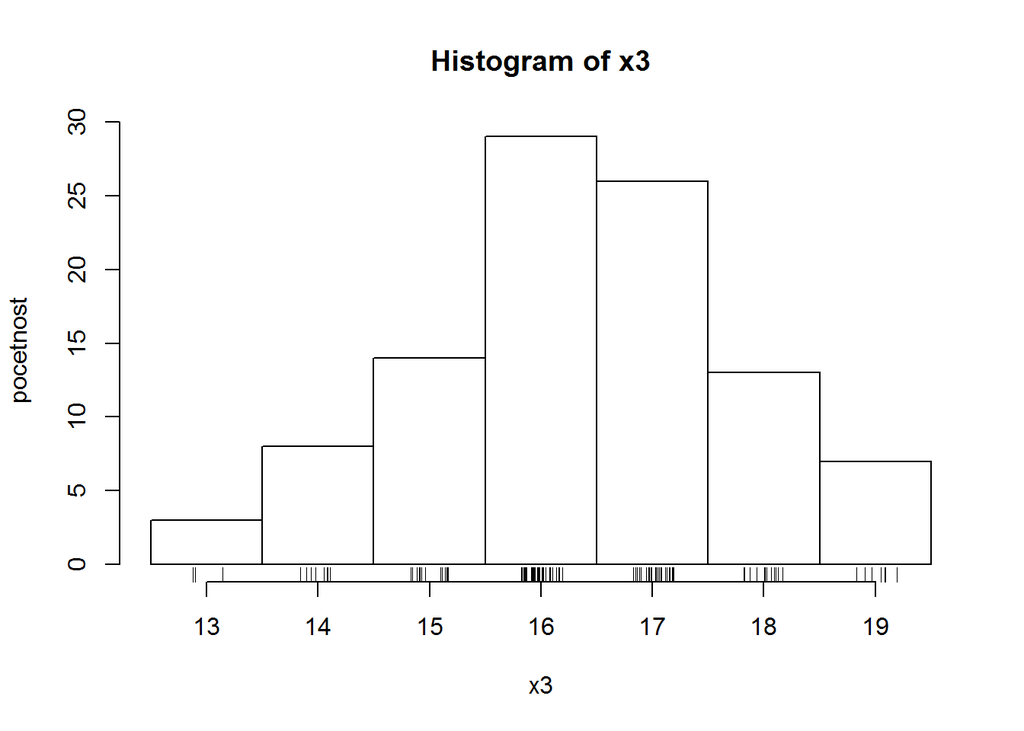

```r
hist(x3, breaks=12.5:19.5, ylab="pocetnost")  # histogram so stredmi kategorii v celych cislach
rug(jitter(x3, factor=1))   # kobercovy graf
```

### Krabicovy graf (boxplot)

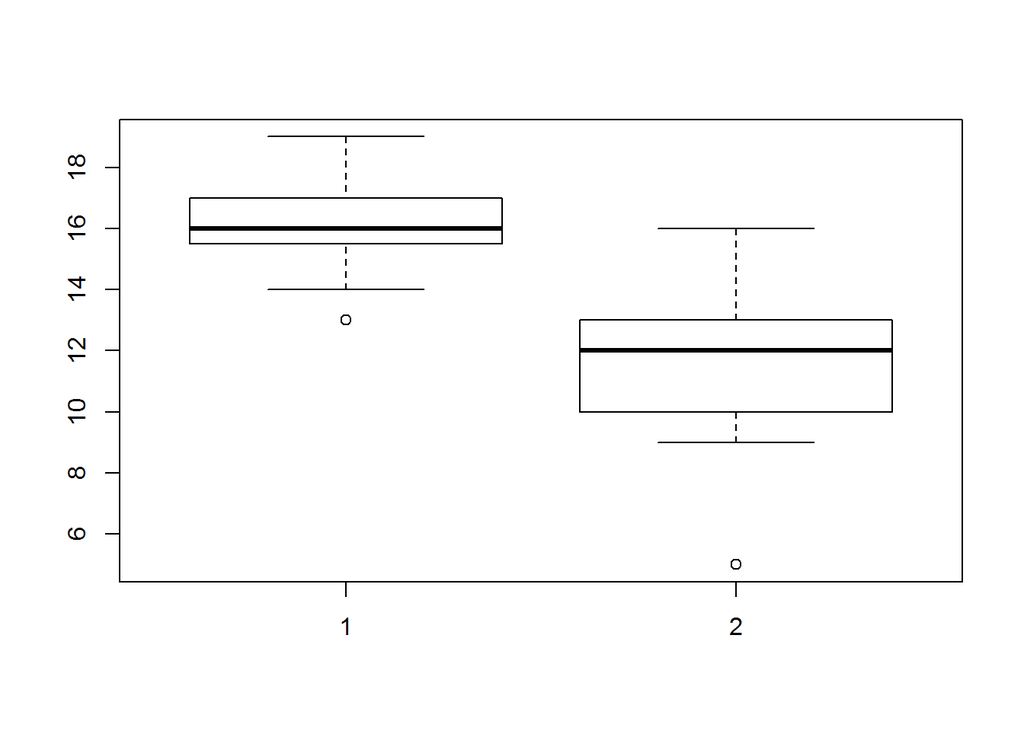

```r
x4 <- rbinom(70, size=20, prob=0.6)
boxplot(x3, x4)
```

S intervalom spolahlivosti pre median a sirkou umernou rozsahu vzorky.

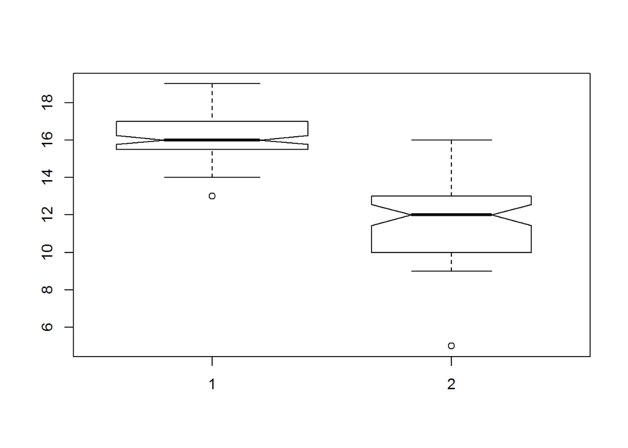

```r
boxplot(x3, x4, notch=T, varwidth = T)
```

## 2.3 Cvičenie

Vygenerujte vzorku nahodnych cisel rozsahu aspon 10 hodnot (z ľubovolneho rozdelenia).

Definujte funkciu podla vztahu na vypocet vyberovej standardnej odchylky a pomocou nej ju aj vypocitajte.

Vypocitajte interkvartilove rozpatie pomocou kvantilov.

Zobrazte histogram s relativnou pocetnostou na osi y, a spolu s nim aj hustotu predpokladaneho parametrickeho rozdelenia.

# Bodove intervalovee odhady

Vela krat pozname rozdelenie nahodnej premennej (NP) a potrebujeme si vytvorit predstavu o jeho parametroch, ktore nepozname, napr. o strednej hodnote ci disperzii normalneho rozdelenia. Vieme vypocitat priemernu hodnotu ci standardnu odchylku z vyberu (pozorovanych hodnot) - bodove odhady, ktore su so zvysujucim sa rozsahom vyberu presnejsie, ale ako presne? O tom hovoria intervaly spolahlivosti.

## Pomer proportion

Priklad: 42 zo 100 opytanych nakupujucich ma rado znacku ABC. Ako prezentovat prefenciu sirsej populacie ludi?

Riesenie: Bodovy odhad je zjavny uz z prieskumu.

```r
p <- 42/100
```

Ak X by bola nahodna premenna, ze sa (nahodne vybraty) clovek bud rozhodne pre ABC (X=1) alebo nie (X=0), pomer p by sme dostali ako priemer z realizacii X, teda p=sum(x)/n, kde x by boli konkretne odpovede x=(1,1,0,1,0,0,0,1,…). Kedze X ma alternativne rozdelenie (s parametrom a zaroven strednou hodnotou p), jeho rozptyl je D(X)=p(1-p). Nahodna premenna Y=sum(X)/n ma tiez strednu hodnotu E(Y)=E(X)=p, no rozptylom D(Y)=p(1-p)/n. Teda cim by sme mali vacsi vyber respondentov, tym “uzsia by bola slucka” okolo odhadovaneho (neznameho) parametra p. Pri dostatocne velkom n bude mat nah.premenna Z=[Y-E(Y)]/SD(Y) normalne rozdelenie N(0,1), pricom SD(Y)=sqrt(D(Y)/n)=SE(X) mozme odhadnut

```r
( se <- sqrt(p*(1-p)/100) )
```

```
## [1] 0.04935585
```

co nam pomoze lokalizovat Y. Kedze Z sa s pravdepodobnostou 1. 0.68 zrealizuje medzi (-1,1) 2. 0.95 vyskytne medzi (-2,2) 3. 0.998 nadobudne hodnotu medzi (-3,3) tak nah.premenna Y bude (napr. s 1-alpha = 95% pravdepodobnostou)

```r
alpha <- 0.05
```

nadobudat hodnoty medzi hranicami

```r
p + c(-1,1)*qnorm(1-alpha/2)*se
```

```
## [1] 0.3232643 0.5167357
```

Podobny vysledok (pocitany s presnou hodnotou SE) da vstavana funkcia

```r
prop.test(42, n=100, conf.level=1-alpha)$conf.int
```

```
## [1] 0.3233236 0.5228954
## attr(,"conf.level")
## [1] 0.95
```

Keby sme sa napr. pytali iba 20 ludi (a v roznych dnoch), pocas 50 dni by sme dostali taketo 90% intervaly pre parameter p

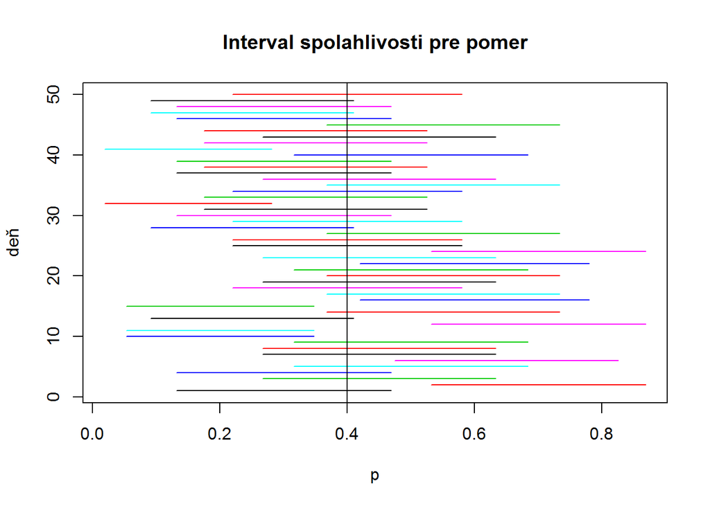

```r
m <- 50; n <- 20; p0 <- 0.4;
p <-  rbinom(m,n,p0)/n
se <- sqrt(p*(1-p)/n)
alpha <- 0.10
matplot(rbind(p - qnorm(1-alpha/2)*se, p + qnorm(1-alpha/2)*se),
        rbind(1:m,1:m),
        type="l", lty=1, xlab="p", ylab="deň", main="Interval spolahlivosti pre pomer"
)
abline(v=p0) # skutocna hodnota parametra
```